# BNCI Assignment 2

# BNCI Assignment 2

## Preliminaries

### Loading data

```r
data_raw <- read.csv("winequality-white.csv", sep=";")
head(data_raw)
```

|  | fixed.acidity | volatile.acidity | citric.acid | residual.sugar | chlorides | free.sulfur.dioxide | total.sulfur.dioxide | density | pH | sulphates | alcohol | quality |
| --- | --- | --- | --- | --- | --- | --- | --- | --- | --- | --- | --- | --- |
| 1 | 7.0 | 0.27 | 0.36 | 20.7 | 0.045 | 45 | 170 | 1.0010 | 3.00 | 0.45 | 8.8 | 6 |
| 2 | 6.3 | 0.30 | 0.34 | 1.6 | 0.049 | 14 | 132 | 0.9940 | 3.30 | 0.49 | 9.5 | 6 |
| 3 | 8.1 | 0.28 | 0.40 | 6.9 | 0.050 | 30 | 97 | 0.9951 | 3.26 | 0.44 | 10.1 | 6 |
| 4 | 7.2 | 0.23 | 0.32 | 8.5 | 0.058 | 47 | 186 | 0.9956 | 3.19 | 0.40 | 9.9 | 6 |
| 5 | 7.2 | 0.23 | 0.32 | 8.5 | 0.058 | 47 | 186 | 0.9956 | 3.19 | 0.40 | 9.9 | 6 |
| 6 | 8.1 | 0.28 | 0.40 | 6.9 | 0.050 | 30 | 97 | 0.9951 | 3.26 | 0.44 | 10.1 | 6 |

### Inspecting data

#### Plotting raw data

```r
# variable_names <- names(data_raw)
#
# # Add a small value to zeros in citric.acid, such that log transforms can be applied
# # The rest of the variables seem all positive
# data_plot <- data_raw
# data_plot$citric.acid[data_plot$citric.acid == 0] <- 0.00000001
#
# # Create a directory to save plots if needed
# plot_directory = "plots_A2"
#
# if (!dir.exists(plot_directory)) {
#   dir.create(plot_directory)
# }
#
# # Loop through variable pairs for plotting
# for (i in 1:(length(variable_names) - 1)) {
#   for (j in (i + 1):length(variable_names)) {
#     #if (i == 1 & j == 2){
#       var_x <- variable_names[i]
#       var_y <- variable_names[j]
#
#       # Base plot
#       plot(data_plot[[var_x]], data_plot[[var_y]],
#            xlab = var_x, ylab = var_y,
#            pch = 19, main = paste(var_y, "vs", var_x))
#
#       # Fit linear model
#       model <- lm(data_plot[[var_y]] ~ data_plot[[var_x]])
#       abline(model, col = 2)
#
#       # Extract and display coefficient and p-value
#       summary_model <- summary(model)
#       coef <- summary_model$coefficients[2, "Estimate"]
#       pval <- summary_model$coefficients[2, "Pr(>|t|)"]
#       text(x = 0.7 * max(data_plot[[var_x]], na.rm = TRUE),
#            y = 0.9 * max(data_plot[[var_y]], na.rm = TRUE),
#            labels = paste("Coeff =", round(coef, 3), "\nP-value =", round(pval, 3)), col = "blue")
#
#       # Save the plot
#       file_name <- paste0(plot_directory, "/", var_y, "_vs_", var_x, ".png")
#       dev.copy(png, file_name)
#       dev.off()
#
#       # Log transformation plots
#       if (all(data_plot[[var_x]] > 0) && all(data_plot[[var_y]] > 0)) { # Log works only for positive values
#         plot(log(data_plot[[var_x]]), log(data_plot[[var_y]]),
#              xlab = paste("log(", var_x, ")", sep = ""),
#              ylab = paste("log(", var_y, ")", sep = ""),
#              pch = 19, main = paste("log(", var_y, ") vs log(", var_x, ")"))
#
#         # Fit linear model for log-transformed data
#         model_log <- lm(log(data_plot[[var_y]]) ~ log(data_plot[[var_x]]))
#         abline(model_log, col = 2)
#
#         # Extract and display coefficient and p-value for log-transformed data
#         summary_model_log <- summary(model_log)
#         coef_log <- summary_model_log$coefficients[2, "Estimate"]
#         pval_log <- summary_model_log$coefficients[2, "Pr(>|t|)"]
#         text(x = 0.7 * max(log(data_plot[[var_x]]), na.rm = TRUE),
#              y = 0.9 * max(log(data_plot[[var_y]]), na.rm = TRUE),
#              labels = paste("Coeff =", round(coef_log, 3), "\nP-value =", round(pval_log, 3)), col = "blue")
#
#         # Save the log-transformed plot
#         log_file_name <- paste0(plot_directory, "/", var_y, "_vs_log_", var_x, ".png")
#         dev.copy(png, log_file_name)
#         dev.off()
#     #}
#     }
#   }
# }
```

#### Residual plots

```r
# Create a directory to save residual plots if needed
# plot_directory = "res_plots_A2"
# if (!dir.exists(plot_directory)) {
#   dir.create(plot_directory)
# }
#
# # Loop through variable pairs for residual plots
# for (i in 1:(length(variable_names) - 1)) {
#   for (j in (i + 1):length(variable_names)) {
#     var_x <- variable_names[i]
#     var_y <- variable_names[j]
#
#     # Fit the linear model for raw data
#     model_raw <- lm(data_plot[[var_y]] ~ data_plot[[var_x]])
#     residuals_raw <- residuals(model_raw)
#
#     # Plot residuals for raw data
#     plot(data_plot[[var_x]], residuals_raw,
#          xlab = var_x, ylab = paste("Residuals of", var_y),
#          pch = 19, main = paste("Residuals of", var_y, "vs", var_x))
#
#     # Add a horizontal line at zero (representing the fitted model)
#     abline(h = 0, col = "red", lwd = 2, lty = 2)
#
#     # Save the residual plot for raw data
#     file_name_raw <- paste0(plot_directory, "/raw_residuals_", var_y, "_vs_", var_x, ".png")
#     dev.copy(png, file_name_raw)
#     dev.off()
#
#     # If both variables are positive, do the same for log-transformed data
#     if (all(data_plot[[var_x]] > 0) && all(data_plot[[var_y]] > 0)) {
#       # Fit the linear model for log-transformed data
#       model_log <- lm(log(data_plot[[var_y]]) ~ log(data_plot[[var_x]]))
#       residuals_log <- residuals(model_log)
#
#       # Plot residuals for log-transformed data
#       plot(log(data_plot[[var_x]]), residuals_log,
#            xlab = paste("log(", var_x, ")", sep = ""),
#            ylab = paste("Residuals of log(", var_y, ")", sep = ""),
#            pch = 19, main = paste("Residuals of log(", var_y, ") vs log(", var_x, ")"))
#
#       # Add a horizontal line at zero (representing the fitted model)
#       abline(h = 0, col = "red", lwd = 2, lty = 2)
#
#       # Save the residual plot for log-transformed data
#       file_name_log <- paste0(plot_directory, "/log_residuals_", var_y, "_vs_", var_x, ".png")
#       dev.copy(png, file_name_log)
#       dev.off()
#     }
#   }
# }
```

### Preprocessing

#### Applying log to alcohol seems useful

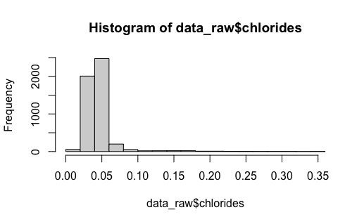

```r
hist(data_raw$chlorides)
```

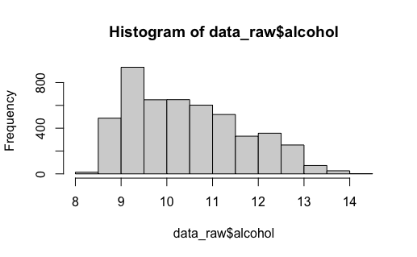

```r
hist(data_raw$alcohol)
```

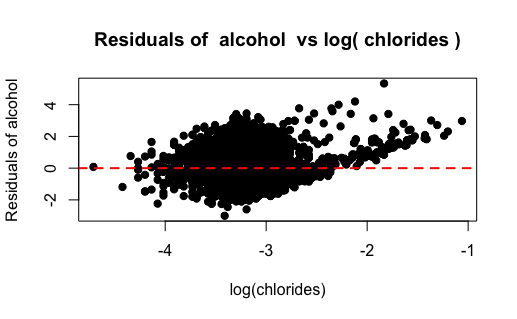

```r
var_x <- "chlorides"
var_y <- "alcohol"
plot_directory = "res_plots_A2"
data_plot = data_raw

if (all(data_plot[[var_x]] > 0) && all(data_plot[[var_y]] > 0)) {
      # Fit the linear model for log-transformed data
      model_log <- lm(data_plot[[var_y]] ~ log(data_plot[[var_x]]))
      residuals_log <- residuals(model_log)

      # Plot residuals for log-transformed data
      plot(log(data_plot[[var_x]]), residuals_log,
           xlab = paste("log(", var_x, ")", sep = ""),
           ylab = paste("Residuals of ", var_y, "", sep = ""),
           pch = 19, main = paste("Residuals of ", var_y, " vs log(", var_x, ")"))

      # Add a horizontal line at zero (representing the fitted model)
      abline(h = 0, col = "red", lwd = 2, lty = 2)

      # Save the residual plot for log-transformed data
      file_name_log <- paste0(plot_directory, "/log_residuals_", var_y, "_vs_", var_x, ".png")
      dev.copy(png, file_name_log)
      dev.off()
}
```

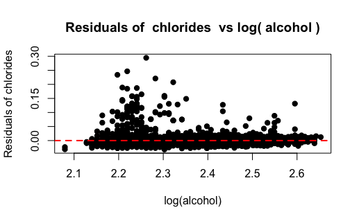

```r
var_x <- "alcohol"
var_y <- "chlorides"

if (all(data_plot[[var_x]] > 0) && all(data_plot[[var_y]] > 0)) {
      # Fit the linear model for log-transformed data
      model_log <- lm(data_plot[[var_y]] ~ log(data_plot[[var_x]]))
      residuals_log <- residuals(model_log)

      # Plot residuals for log-transformed data
      plot(log(data_plot[[var_x]]), residuals_log,
           xlab = paste("log(", var_x, ")", sep = ""),
           ylab = paste("Residuals of ", var_y, "", sep = ""),
           pch = 19, main = paste("Residuals of ", var_y, " vs log(", var_x, ")"))

      # Add a horizontal line at zero (representing the fitted model)
      abline(h = 0, col = "red", lwd = 2, lty = 2)

      # Save the residual plot for log-transformed data
      file_name_log <- paste0(plot_directory, "/log_residuals_", var_y, "_vs_", var_x, ".png")
      dev.copy(png, file_name_log)
      dev.off()
}
```

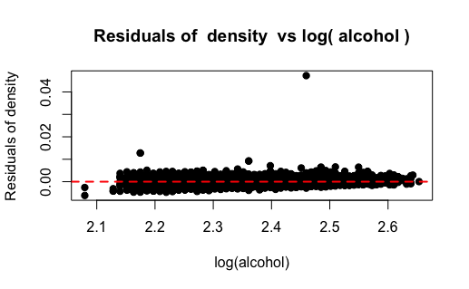

```r
var_x <- "alcohol"
var_y <- "density"

if (all(data_plot[[var_x]] > 0) && all(data_plot[[var_y]] > 0)) {
      # Fit the linear model for log-transformed data
      model_log <- lm(data_plot[[var_y]] ~ log(data_plot[[var_x]]))
      residuals_log <- residuals(model_log)

      # Plot residuals for log-transformed data
      plot(log(data_plot[[var_x]]), residuals_log,
           xlab = paste("log(", var_x, ")", sep = ""),
           ylab = paste("Residuals of ", var_y, "", sep = ""),
           pch = 19, main = paste("Residuals of ", var_y, " vs log(", var_x, ")"))

      # Add a horizontal line at zero (representing the fitted model)
      abline(h = 0, col = "red", lwd = 2, lty = 2)

      # Save the residual plot for log-transformed data
      file_name_log <- paste0(plot_directory, "/log_residuals_", var_y, "_vs_", var_x, ".png")
      dev.copy(png, file_name_log)
      dev.off()
}
```

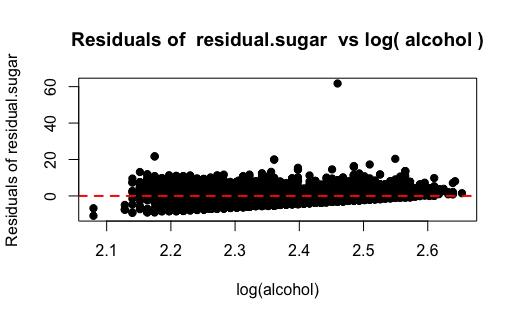

```r
var_x <- "alcohol"
var_y <- "residual.sugar"

if (all(data_plot[[var_x]] > 0) && all(data_plot[[var_y]] > 0)) {
      # Fit the linear model for log-transformed data
      model_log <- lm(data_plot[[var_y]] ~ log(data_plot[[var_x]]))
      residuals_log <- residuals(model_log)

      # Plot residuals for log-transformed data
      plot(log(data_plot[[var_x]]), residuals_log,
           xlab = paste("log(", var_x, ")", sep = ""),
           ylab = paste("Residuals of ", var_y, "", sep = ""),
           pch = 19, main = paste("Residuals of ", var_y, " vs log(", var_x, ")"))

      # Add a horizontal line at zero (representing the fitted model)
      abline(h = 0, col = "red", lwd = 2, lty = 2)

      # Save the residual plot for log-transformed data
      file_name_log <- paste0(plot_directory, "/log_residuals_", var_y, "_vs_", var_x, ".png")
      dev.copy(png, file_name_log)
      dev.off()
}
```

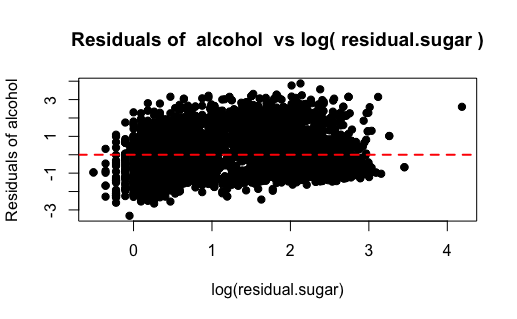

```r
var_x <- "residual.sugar"
var_y <- "alcohol"

if (all(data_plot[[var_x]] > 0) && all(data_plot[[var_y]] > 0)) {
      # Fit the linear model for log-transformed data
      model_log <- lm(data_plot[[var_y]] ~ log(data_plot[[var_x]]))
      residuals_log <- residuals(model_log)

      # Plot residuals for log-transformed data
      plot(log(data_plot[[var_x]]), residuals_log,
           xlab = paste("log(", var_x, ")", sep = ""),
           ylab = paste("Residuals of ", var_y, "", sep = ""),
           pch = 19, main = paste("Residuals of ", var_y, " vs log(", var_x, ")"))

      # Add a horizontal line at zero (representing the fitted model)
      abline(h = 0, col = "red", lwd = 2, lty = 2)

      # Save the residual plot for log-transformed data
      file_name_log <- paste0(plot_directory, "/log_residuals_", var_y, "_vs_", var_x, ".png")
      dev.copy(png, file_name_log)
      dev.off()
}
```

#### Outlier removal

```r
# Removing residual sugar outlier
max_sugar <- max(data_raw$residual.sugar)
h <- hist(data_raw$residual.sugar, plot = FALSE)

plot(h, xlab = "Residual sugar concentration [g/L]", ylab = "Frequency",
     main = "Histogram of residual sugar in raw data", col = "blue")
abline(v = max_sugar, col = "red", lwd = 2, lty = 2)
```

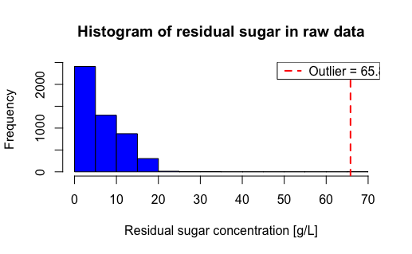

```r
legend("topright",
       legend = paste("Outlier =", paste(round(max_sugar, 2), "g/L")),
       col = "red",
       lty = 2,
       lwd = 2)
```

```r
print(max_sugar)
```

```
[1] 65.8
```

```r
data_no_outlier <- data_raw[data_raw$residual.sugar != max_sugar,]
print(max(data_no_outlier$residual.sugar)) # outlier was removed
```

```
[1] 31.6
```

#### Plot outlier removal result

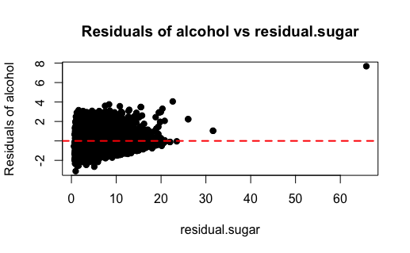

```r
var_x <- "residual.sugar"
var_y <- "alcohol"

# Plot raw data
data_plot = data_raw
# Fit the linear model for raw data
model_raw <- lm(data_plot[[var_y]] ~ data_plot[[var_x]])
residuals_raw <- residuals(model_raw)

# Plot residuals for raw data
plot(data_plot[[var_x]], residuals_raw,
     xlab = var_x, ylab = paste("Residuals of", var_y),
     pch = 19, main = paste("Residuals of", var_y, "vs", var_x))

# Add a horizontal line at zero (representing the fitted model)
abline(h = 0, col = "red", lwd = 2, lty = 2)
```

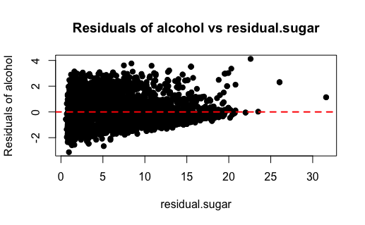

```r
# Remove outlier and plot result
data_plot = data_no_outlier
# Fit the linear model for raw data
model_raw <- lm(data_plot[[var_y]] ~ data_plot[[var_x]])
residuals_raw <- residuals(model_raw)

# Plot residuals for raw data
plot(data_plot[[var_x]], residuals_raw,
     xlab = var_x, ylab = paste("Residuals of", var_y),
     pch = 19, main = paste("Residuals of", var_y, "vs", var_x))

# Add a horizontal line at zero (representing the fitted model)
abline(h = 0, col = "red", lwd = 2, lty = 2)
```

#### Combined preprocessing: Outlier removal, normalizing, log(alcohol)

```r
max_sugar <- max(data_raw$residual.sugar)
data_no_outlier <- data_raw[data_raw$residual.sugar != max_sugar,]
data_normalized <- data_no_outlier
data_normalized_incl_outlier <- data_raw

# Ordered factor for quality, such that lavaan applies polychoric relationship for quality
data_normalized$quality <- ordered(data_no_outlier$quality, levels = sort(unique(data_no_outlier$quality)))

# log transform of alcohol
data_normalized$alcohol <- log(data_normalized$alcohol)

# scaling for normalization
data_normalized[ , 1:(ncol(data_normalized) - 1)] <- scale(data_normalized[ , 1:(ncol(data_normalized) - 1)])
head(data_normalized)
```

|  | fixed.acidity | volatile.acidity | citric.acid | residual.sugar | chlorides | free.sulfur.dioxide | total.sulfur.dioxide | density | pH | sulphates | alcohol | quality |
| --- | --- | --- | --- | --- | --- | --- | --- | --- | --- | --- | --- | --- |
| 1 | 0.1723126 | -0.08074572 | 0.21379048 | 2.8635703 | -0.03508996 | 0.5696374 | 0.7445367 | 2.389888725 | -1.24662114 | -0.348864459 | -1.4889000 | 6 |
| 2 | -0.6572224 | 0.21828007 | 0.04846368 | -0.9556654 | 0.14800595 | -1.2534207 | -0.1495541 | -0.006228829 | 0.74028527 | 0.001700206 | -0.8235207 | 6 |
| 3 | 1.4758676 | 0.01892955 | 0.54444409 | 0.1041225 | 0.19377993 | -0.3124875 | -0.9730587 | 0.370303929 | 0.47536442 | -0.436505625 | -0.2911167 | 6 |
| 4 | 0.4093226 | -0.47944677 | -0.11686313 | 0.4240585 | 0.55997175 | 0.6872540 | 1.1209959 | 0.541455183 | 0.01175292 | -0.787070291 | -0.4649868 | 6 |
| 5 | 0.4093226 | -0.47944677 | -0.11686313 | 0.4240585 | 0.55997175 | 0.6872540 | 1.1209959 | 0.541455183 | 0.01175292 | -0.787070291 | -0.4649868 | 6 |
| 6 | 1.4758676 | 0.01892955 | 0.54444409 | 0.1041225 | 0.19377993 | -0.3124875 | -0.9730587 | 0.370303929 | 0.47536442 | -0.436505625 | -0.2911167 | 6 |

```r
# Including outlier for comparison
data_normalized_incl_outlier$quality <- ordered(data_normalized_incl_outlier$quality,
                                                levels = sort(unique(data_normalized_incl_outlier$quality))
                                                )
data_normalized_incl_outlier[ , 1:(ncol(data_normalized_incl_outlier) - 1)] <- scale(data_raw[ , 1:(ncol(data_raw) - 1)]) # scaling
```

```r
class(data_normalized["quality"])
```

```
[1] "data.frame"
```

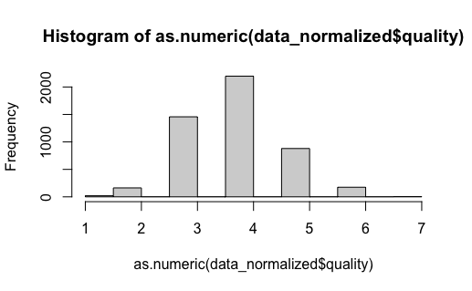

```r
hist(as.numeric(data_normalized$quality))
```

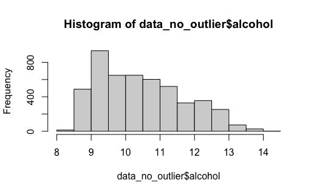

```r
hist(data_no_outlier$alcohol)
```

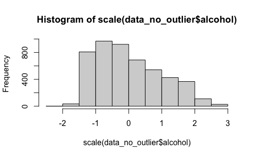

```r
hist(scale(data_no_outlier$alcohol))
```

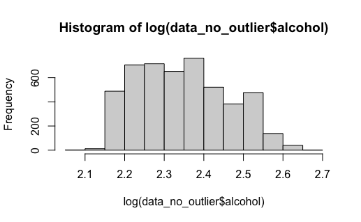

```r
hist(log(data_no_outlier$alcohol))
```

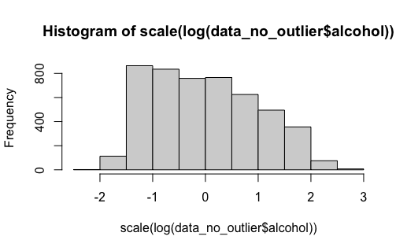

```r
hist(scale(log(data_no_outlier$alcohol)))
```

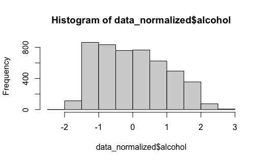

```r
hist(data_normalized$alcohol)
```

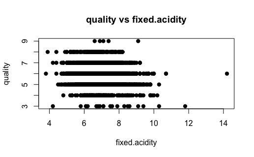

```r
# Sanity check: Ordered factor does not affect plotting
#data_test <- data_raw
#data_test$quality <- ordered(data_test$quality, levels = sort(unique(data_test$quality)))
data_test <- data_normalized
var_x = "fixed.acidity"
var_y = "quality"
plot(data_raw$fixed.acidity, data_raw$quality,
         xlab = var_x, ylab = var_y,
         pch = 19, main = paste(var_y, "vs", var_x))
```

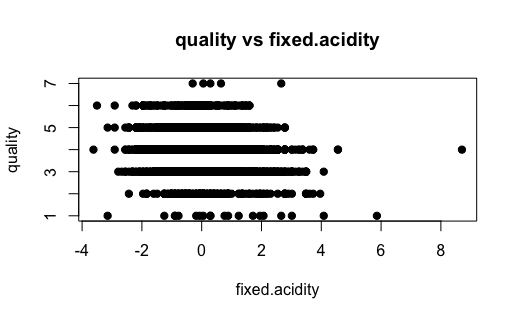

```r
plot(data_test$fixed.acidity, data_test$quality,
         xlab = var_x, ylab = var_y,
         pch = 19, main = paste(var_y, "vs", var_x))
```

## Our Model

### Initial iteration

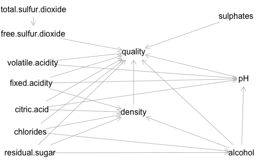

```r
# Our proposed model
library(dagitty)

graph_white <- dagitty('dag {
bb="0,0,1,1"
alcohol [pos="0.713,0.893"]
chlorides [pos="0.165,0.786"]
citric.acid [pos="0.169,0.671"]
density [pos="0.433,0.687"]
fixed.acidity [pos="0.167,0.538"]
free.sulfur.dioxide [pos="0.172,0.281"]
pH [pos="0.719,0.515"]
quality [outcome,pos="0.433,0.378"]
residual.sugar [exposure,pos="0.164,0.895"]
sulphates [pos="0.699,0.194"]
total.sulfur.dioxide [pos="0.173,0.156"]
volatile.acidity [pos="0.171,0.434"]
alcohol -> density
alcohol -> pH
alcohol -> quality
chlorides -> alcohol
chlorides -> density
chlorides -> quality
citric.acid -> density
citric.acid -> pH
citric.acid -> quality
density -> quality
fixed.acidity -> density
fixed.acidity -> pH
fixed.acidity -> quality
free.sulfur.dioxide -> quality
pH -> quality
residual.sugar -> alcohol
residual.sugar -> density
residual.sugar -> quality
sulphates -> quality
total.sulfur.dioxide -> free.sulfur.dioxide
volatile.acidity -> pH
volatile.acidity -> quality
}')

#free.sulfur.dioxide -> volatile.acidity

plot(graph_white)
```

```r
library(lavaan)
CorM <- lavCor(data_normalized)
results <- localTests(graph_white, sample.cov = CorM, sample.nobs = nrow(data_normalized), abbreviate.names = FALSE)
results_ordered <- results[order(-abs(results$estimate), results$p.value),]
results_ordered
```

|  | estimate | p.value | 2.5% | 97.5% |
| --- | --- | --- | --- | --- |
| density _\|\|_ total.sulfur.dioxide | 0.5409590859 | 0.000000e+00 | 0.523706437 | 0.564707687 |
| alcohol _\|\|_ total.sulfur.dioxide | -0.4490467735 | 8.558579e-251 | -0.472822899 | -0.427409202 |
| residual.sugar _\|\|_ total.sulfur.dioxide | 0.4059599447 | 1.684506e-199 | 0.382872900 | 0.430132217 |
| free.sulfur.dioxide _\|\|_ residual.sugar | 0.3073563591 | 2.199840e-109 | 0.281894596 | 0.332785355 |
| density _\|\|_ free.sulfur.dioxide | 0.3063695052 | 1.196975e-108 | 0.280889165 | 0.331811849 |
| citric.acid _\|\|_ fixed.acidity | 0.2888575497 | 4.363503e-96 | 0.263061816 | 0.314535774 |
| quality _\|\|_ total.sulfur.dioxide \| free.sulfur.dioxide | -0.2588988970 | 1.146140e-76 | -0.284973972 | -0.232619646 |
| alcohol _\|\|_ free.sulfur.dioxide | -0.2498774325 | 2.468841e-71 | -0.276064979 | -0.223469666 |
| chlorides _\|\|_ total.sulfur.dioxide | 0.1988150901 | 4.004245e-45 | 0.171772330 | 0.225607916 |
| pH _\|\|_ residual.sugar \| alcohol | -0.1638998362 | 5.907327e-31 | -0.191052111 | -0.136517605 |

[output cut: 34 more lines]

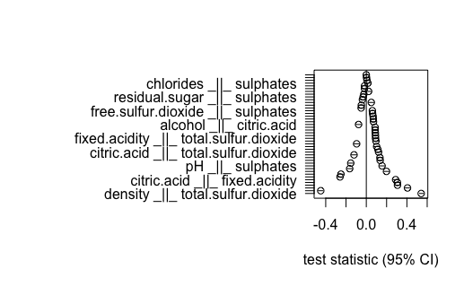

```r
# , fig.width=16, fig.height=8
plotLocalTestResults(results)
#par = c("width = 12", "height=800", "res=150")
par(mar = c(5, 20, 4, 2)) #, cex.axis = 1.5, cex.lab = 2
```

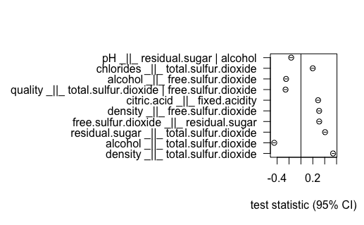

```r
plotLocalTestResults(results, n=10, auto.margin = FALSE)
```

### Update 1 - total.sulfite.dioxide -> density

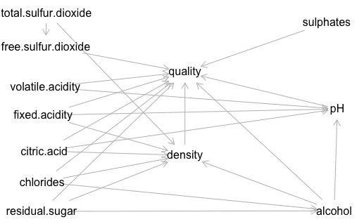

```r
graph_white_1 <- dagitty('dag {
bb="0,0,1,1"
alcohol [pos="0.713,0.893"]
chlorides [pos="0.165,0.786"]
citric.acid [pos="0.169,0.671"]
density [pos="0.433,0.687"]
fixed.acidity [pos="0.167,0.538"]
free.sulfur.dioxide [pos="0.172,0.281"]
pH [pos="0.719,0.515"]
quality [outcome,pos="0.433,0.378"]
residual.sugar [exposure,pos="0.164,0.895"]
sulphates [pos="0.699,0.194"]
total.sulfur.dioxide [pos="0.173,0.156"]
volatile.acidity [pos="0.171,0.434"]
alcohol -> density
alcohol -> pH
alcohol -> quality
chlorides -> alcohol
chlorides -> density
chlorides -> quality
citric.acid -> density
citric.acid -> pH
citric.acid -> quality
density -> quality
fixed.acidity -> density
fixed.acidity -> pH
fixed.acidity -> quality
free.sulfur.dioxide -> quality
pH -> quality
residual.sugar -> alcohol
residual.sugar -> density
residual.sugar -> quality
sulphates -> quality
total.sulfur.dioxide -> free.sulfur.dioxide
volatile.acidity -> pH
volatile.acidity -> quality

total.sulfur.dioxide -> density

}')

plot(graph_white_1)
```

```r
CorM <- lavCor(data_normalized)
results <- localTests(graph_white_1, sample.cov = CorM, sample.nobs = nrow(data_normalized), abbreviate.names = FALSE)
results_ordered <- results[order(-abs(results$estimate), results$p.value),]
results_ordered
```

|  | estimate | p.value | 2.5% | 97.5% |
| --- | --- | --- | --- | --- |
| alcohol _\|\|_ total.sulfur.dioxide | -0.4490467735 | 8.558579e-251 | -0.472822899 | -0.427409202 |
| residual.sugar _\|\|_ total.sulfur.dioxide | 0.4059599447 | 1.684506e-199 | 0.382872900 | 0.430132217 |
| free.sulfur.dioxide _\|\|_ residual.sugar | 0.3073563591 | 2.199840e-109 | 0.281894596 | 0.332785355 |
| citric.acid _\|\|_ fixed.acidity | 0.2888575497 | 4.363503e-96 | 0.263061816 | 0.314535774 |
| alcohol _\|\|_ free.sulfur.dioxide | -0.2498774325 | 2.468841e-71 | -0.276064979 | -0.223469666 |
| chlorides _\|\|_ total.sulfur.dioxide | 0.1988150901 | 4.004245e-45 | 0.171772330 | 0.225607916 |
| pH _\|\|_ residual.sugar \| alcohol | -0.1638998362 | 5.907327e-31 | -0.191052111 | -0.136517605 |
| pH _\|\|_ sulphates | 0.1555501522 | 5.274248e-28 | 0.128101257 | 0.182776946 |
| citric.acid _\|\|_ volatile.acidity | -0.1533322774 | 3.021562e-27 | -0.180579050 | -0.125865629 |
| density _\|\|_ pH \| alcohol, citric.acid, fixed.acidity | 0.1363826236 | 8.165515e-22 | 0.108781410 | 0.163782642 |

[output cut: 33 more lines]

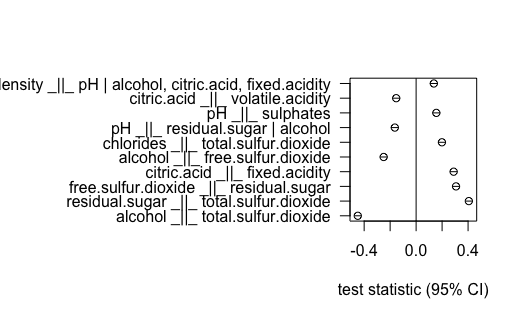

```r
plotLocalTestResults(results, n=10)
```

As expected this resolves the worst misfitting.

```r
max_sugar <- max(data_raw$residual.sugar)
print(max_sugar)
```

```
[1] 65.8
```

```r
data_no_outlier <- data_raw[data_raw$residual.sugar != max_sugar,]
data_normalized_no_outlier <- data_no_outlier

# Ordered factor for quality, such that lavaan applies polychoric relationship for quality
data_normalized_no_outlier$quality <- ordered(data_normalized$quality, levels = sort(unique(data_normalized_no_outlier$quality)))
data_normalized_no_outlier[ , 1:(ncol(data_normalized_no_outlier) - 1)] <- scale(data_raw[ , 1:(ncol(data_raw) - 1)]) # scaling
head(data_normalized_no_outlier)
```

[output not shown]

```r
CorM <- lavCor(data_normalized_no_outlier)
results <- localTests(graph_white, sample.cov = CorM, sample.nobs = nrow(data_normalized_no_outlier), abbreviate.names = FALSE)
results_ordered <- results[order(-abs(results$estimate), results$p.value),]
results_ordered
```

|  | estimate | p.value | 2.5% | 97.5% |
| --- | --- | --- | --- | --- |
| density _\|\|_ total.sulfur.dioxide | 0.1421644622 | 1.333088e-23 | 0.1146128458 | 0.169508265 |
| citric.acid _\|\|_ fixed.acidity | 0.0909309692 | 1.783764e-10 | 0.0630823854 | 0.118639698 |
| alcohol _\|\|_ fixed.acidity | -0.0781310024 | 4.326375e-08 | -0.1059094399 | -0.050231635 |
| fixed.acidity _\|\|_ total.sulfur.dioxide | 0.0769430065 | 6.914756e-08 | 0.0490393955 | 0.104727467 |
| residual.sugar _\|\|_ total.sulfur.dioxide | 0.0664483348 | 3.233607e-06 | 0.0385106998 | 0.094282673 |
| citric.acid _\|\|_ volatile.acidity | -0.0657145888 | 4.147737e-06 | -0.0935521904 | -0.037774807 |
| alcohol _\|\|_ total.sulfur.dioxide | -0.0617758810 | 1.510350e-05 | -0.0896304964 | -0.033825096 |
| pH _\|\|_ total.sulfur.dioxide | 0.0488964878 | 6.184574e-04 | 0.0209158178 | 0.076800799 |
| alcohol _\|\|_ volatile.acidity | -0.0432046097 | 2.491653e-03 | -0.0711279730 | -0.015213705 |
| alcohol _\|\|_ sulphates | -0.0414342731 | 3.728255e-03 | -0.0693631970 | -0.013440556 |

[output cut: 34 more lines]

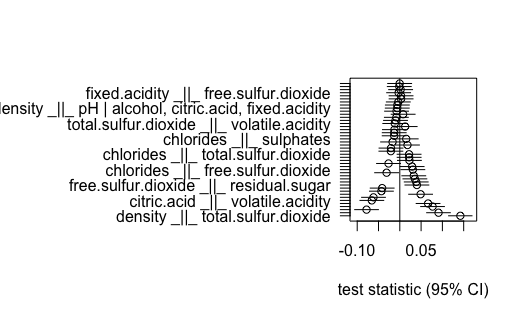

```r
plotLocalTestResults(results)
```

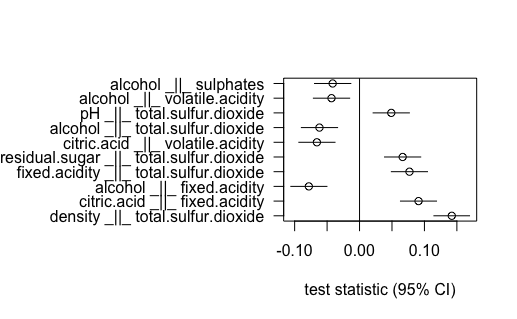

```r
plotLocalTestResults(results, n=10)
```

### Update 2: total.sulfite.dioxide -> alcohol

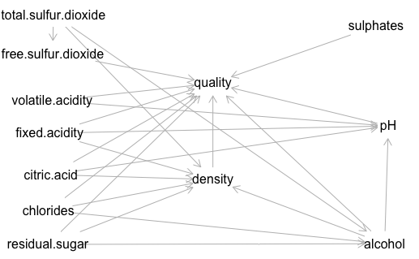

```r
graph_white_2 <- dagitty('dag {
bb="0,0,1,1"
alcohol [pos="0.713,0.893"]
chlorides [pos="0.165,0.786"]
citric.acid [pos="0.169,0.671"]
density [pos="0.433,0.687"]
fixed.acidity [pos="0.167,0.538"]
free.sulfur.dioxide [pos="0.172,0.281"]
pH [pos="0.719,0.515"]
quality [outcome,pos="0.433,0.378"]
residual.sugar [exposure,pos="0.164,0.895"]
sulphates [pos="0.699,0.194"]
total.sulfur.dioxide [pos="0.173,0.156"]
volatile.acidity [pos="0.171,0.434"]
alcohol -> density
alcohol -> pH
alcohol -> quality
chlorides -> alcohol
chlorides -> density
chlorides -> quality
citric.acid -> density
citric.acid -> pH
citric.acid -> quality
density -> quality
fixed.acidity -> density
fixed.acidity -> pH
fixed.acidity -> quality
free.sulfur.dioxide -> quality
pH -> quality
residual.sugar -> alcohol
residual.sugar -> density
residual.sugar -> quality
sulphates -> quality
total.sulfur.dioxide -> free.sulfur.dioxide
volatile.acidity -> pH
volatile.acidity -> quality


total.sulfur.dioxide -> density
total.sulfur.dioxide -> alcohol

}')

plot(graph_white_2)
```

```r
CorM <- lavCor(data_normalized)
results <- localTests(graph_white_2, sample.cov = CorM, sample.nobs = nrow(data_normalized), abbreviate.names = FALSE)
results_ordered <- results[order(-abs(results$estimate), results$p.value),]
results_ordered
```

|  | estimate | p.value | 2.5% | 97.5% |
| --- | --- | --- | --- | --- |
| residual.sugar _\|\|_ total.sulfur.dioxide | 0.405959945 | 1.684506e-199 | 0.382872900 | 0.430132217 |
| free.sulfur.dioxide _\|\|_ residual.sugar | 0.307356359 | 2.199840e-109 | 0.281894596 | 0.332785355 |
| citric.acid _\|\|_ fixed.acidity | 0.288857550 | 4.363503e-96 | 0.263061816 | 0.314535774 |
| chlorides _\|\|_ total.sulfur.dioxide | 0.198815090 | 4.004245e-45 | 0.171772330 | 0.225607916 |
| pH _\|\|_ residual.sugar \| alcohol | -0.163899836 | 5.907327e-31 | -0.191052111 | -0.136517605 |
| pH _\|\|_ sulphates | 0.155550152 | 5.274248e-28 | 0.128101257 | 0.182776946 |
| citric.acid _\|\|_ volatile.acidity | -0.153332277 | 3.021562e-27 | -0.180579050 | -0.125865629 |
| density _\|\|_ pH \| alcohol, citric.acid, fixed.acidity | 0.136382624 | 8.165515e-22 | 0.108781410 | 0.163782642 |
| sulphates _\|\|_ total.sulfur.dioxide | 0.134425762 | 3.041171e-21 | 0.106819568 | 0.161833240 |
| alcohol _\|\|_ fixed.acidity | -0.121128560 | 1.657042e-17 | -0.148638475 | -0.093436724 |

[output cut: 33 more lines]

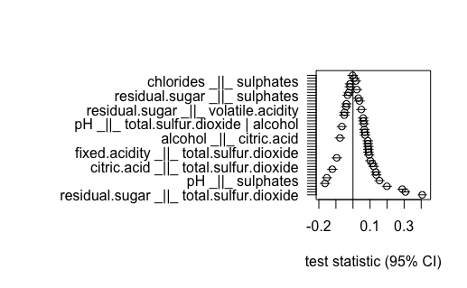

```r
plotLocalTestResults(results)
```

Again, a direct edge is guaranteed to resolve the misfit.

The next large problem is residual.sugar *||* total.sulfur.dioxide. The process of fermentation seems like a fitting context here too. Here, sugar is consumed by yeast to produce alcohol. Sugar that is left when the fermentation process stopped is called residual sugar.

My idea to resolve this independence misfit is to find some latent representation of the fermentation process. I tried several explicit representations but they did not work out. When the SEM models where fit, the latent variable did not seem to express much of the variance. Then Johannes suggested to use implicit latent variables anyways. Those are much easier to fit and test as well.

Domain-wise, I would find that it makes more sense to fit free.sulfur.dioxide <-> residual.sugar, but that did not resolve the independence problem (after fitting this only finds a covariance of 6%)

### Update 3: Implicit latent variableresidual.sugar *||* total.sulfur.dioxide (e.g. Yeast)

#### Just some investigation of the data

```r
# Plot 1: residual.sugar ~ total.sulfur.dioxide
plot(residual.sugar ~ total.sulfur.dioxide, data = data_normalized, pch = 19)
model1 <- lm(residual.sugar ~ total.sulfur.dioxide, data = data_normalized)
abline(model1, col = 2)
```

```r
# Extract and print coefficient and p-value
summary1 <- summary(model1)
print(summary1)
```

```
Call:
lm(formula = residual.sugar ~ total.sulfur.dioxide, data = data_normalized)

Residuals:
    Min      1Q  Median      3Q     Max
-3.5769 -0.6684 -0.2128  0.6030  4.6836

Coefficients:
                      Estimate Std. Error t value Pr(>|t|)
(Intercept)          2.643e-16  1.306e-02    0.00        1
total.sulfur.dioxide 4.060e-01  1.306e-02   31.08   <2e-16 ***
---
Signif. codes:  0 ‘***’ 0.001 ‘**’ 0.01 ‘*’ 0.05 ‘.’ 0.1 ‘ ’ 1

Residual standard error: 0.914 on 4895 degrees of freedom
Multiple R-squared:  0.1648,    Adjusted R-squared:  0.1646
F-statistic: 965.9 on 1 and 4895 DF,  p-value: < 2.2e-16
```

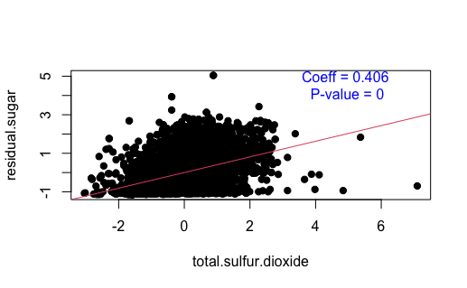

```r
coef1 <- summary1$coefficients["total.sulfur.dioxide", "Estimate"]
pval1 <- summary1$coefficients["total.sulfur.dioxide", "Pr(>|t|)"]
text(x = 0.7 * max(data_normalized$total.sulfur.dioxide),
     y = 0.9 * max(data_normalized$residual.sugar),
     labels = paste("Coeff =", round(coef1, 3), "\nP-value =", round(pval1, 3)), col = "blue")
```

```r
# Plot 2: free.sulfur.dioxide ~ residual.sugar
plot(free.sulfur.dioxide ~ residual.sugar, data = data_normalized, pch = 19)
model2 <- lm(free.sulfur.dioxide ~ residual.sugar, data = data_normalized)
abline(model2, col = 2)
```

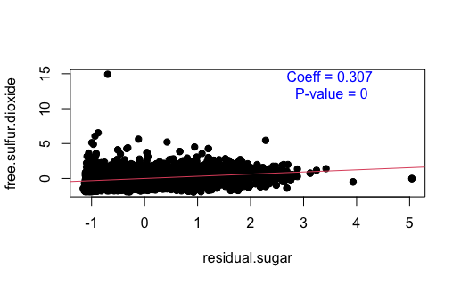

```r
# Extract and print coefficient and p-value
summary2 <- summary(model2)
coef2 <- summary2$coefficients["residual.sugar", "Estimate"]
pval2 <- summary2$coefficients["residual.sugar", "Pr(>|t|)"]
text(x = 0.7 * max(data_normalized$residual.sugar),
     y = 0.9 * max(data_normalized$free.sulfur.dioxide),
     labels = paste("Coeff =", round(coef2, 3), "\nP-value =", round(pval2, 3)), col = "blue")
```

```r
# Plot 3: free.sulfur.dioxide ~ total.sulfur.dioxide
plot(free.sulfur.dioxide ~ total.sulfur.dioxide, data = data_normalized, pch = 19)
model3 <- lm(free.sulfur.dioxide ~ total.sulfur.dioxide, data = data_normalized)
abline(model3, col = 2)
```

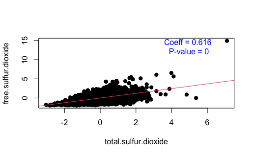

```r
# Extract and print coefficient and p-value
summary3 <- summary(model3)
coef3 <- summary3$coefficients["total.sulfur.dioxide", "Estimate"]
pval3 <- summary3$coefficients["total.sulfur.dioxide", "Pr(>|t|)"]
text(x = 0.7 * max(data_normalized$total.sulfur.dioxide),
     y = 0.9 * max(data_normalized$free.sulfur.dioxide),
     labels = paste("Coeff =", round(coef3, 3), "\nP-value =", round(pval3, 3)), col = "blue")
```